# NCG612_Assignment_1

Donal Conlon

3/15/2022

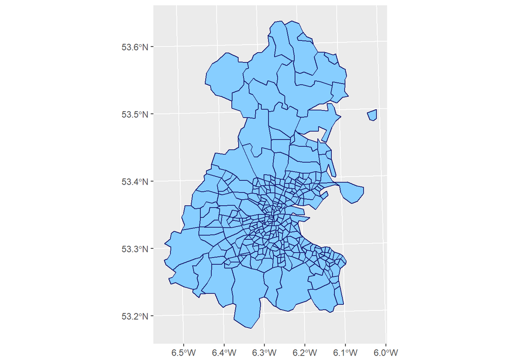

```r
library(sf)
library(ggplot2)
dub_eds <- st_read('~/NCG612/dub_eds.geojson', quiet=TRUE)
ggplot(dub_eds) + geom_sf(fill='skyblue1', col='midnightblue')
```

```r
## Reading in the data, with an illustration of the Dublin Electorate area.
```

```r
library(tidyverse)
dub_trips <- read_csv('~/NCG612/dublin_trips.csv')
lookup <- read_csv('~/NCG612/lookup.csv')
```

The ‘Coombes & Bond’ algorithm, conceived in 2008, utilizes a multidirectional-flow-based approach. Areas are clustered such that; majority of people that work in the area also reside in the area; and the majority of workers that live in the area also work in the area. Clusters are created through bottom-up iterative reassignment, joining together electoral areas, satisfying criteria based on self-containment and size. Crucially, there is a contiguity constraint applied to the algorithm, meaning clusters must be adjoined and not split into parcels of land. Self-containment is the main driving force behind the algorithm. Self-containment is determined by calculating the internal, supply and demand flows.

```r
library(LabourMarketAreas)
dub_trips$amount <- as.numeric(as.character(dub_trips$amount))
cl1 <- findClusters(dub_trips,15000,0.4,80000,0.5,idcom_type='char')
```

```
## [1] "The algorithm has converged."
```

```r
head(cl1$lma$clusterList)
```

```
##    community cluster residents
## 1:     02001     301       872
## 2:     02002     301      2149
## 3:     02003     301      2449
## 4:     02004     301      1240
## 5:     02005     301      1783
## 6:     02006     219      6268
```

Coombes & Bond Algorithm as per stock parameters set by Chris.

```r
library(dplyr)
library(ggplot2)

dub_eds1 <- dub_eds
#Create a copy of dub_eds so we can use the original for each new instance.

dub_eds1 <- dub_eds1 %>% left_join(cl1$lma$clusterList,copy=TRUE, by='community')


dub_eds1$cluster <- as.character(dub_eds1$cluster)


trips_to_work <- dub_trips %>%
group_by(community_work) %>%
summarise(amount=sum(amount)) %>%
rename(community=community_work)


dub_eds1 <- dub_eds1 %>% left_join(trips_to_work)
dub_eds1 <- dub_eds1 %>% left_join(lookup, by=c('community'))
```

In the application exercises, the chosen values for the parameters SCmin and SCtarget ranged from 0.4 to 0.5 and 0.5 to 0.9 respectively. Such high values for SCtarget are needed in countries where large areas show low population density such as; Canada, Russia or Australia. However, lower values suffice for municipalities such as county Dublin or even Brindisi. Logically, to ensure that identified functional areas truly capture labour market links, the self-containment parameter should be no less than 0.5

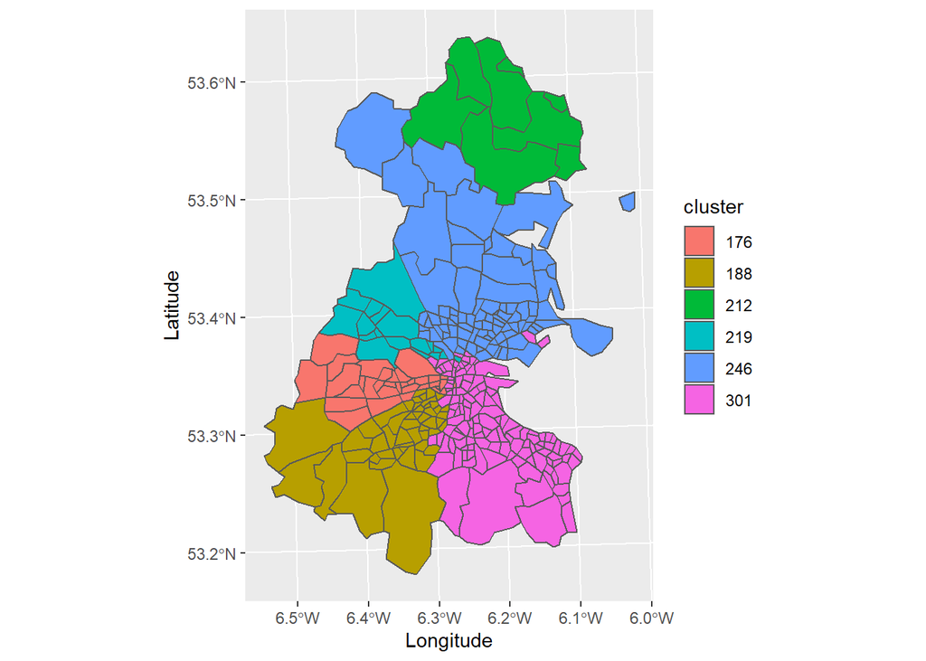

```r
library(ggrepel)
ggplot(dub_eds1,aes(fill=cluster)) +
  xlab('Longitude') + ylab('Latitude') +
geom_sf()
```

Travel to work area 1 makes use of the stock parameters set by Chris in the brief. I reused these as despite varying changes to the parameter models, I struggled to attain a more geographically or aesthetically pleasing division of electoral areas. Almost each area converges to the city centre, save for the most northerly pockets. There isn’t a great variance in size either.

```r
library(LabourMarketAreas)
dub_trips2 <- dub_trips

cl2 <- findClusters(dub_trips2,1500,0.4,8000,0.5,idcom_type='char')
```

```
## [1] "The algorithm has converged."
```

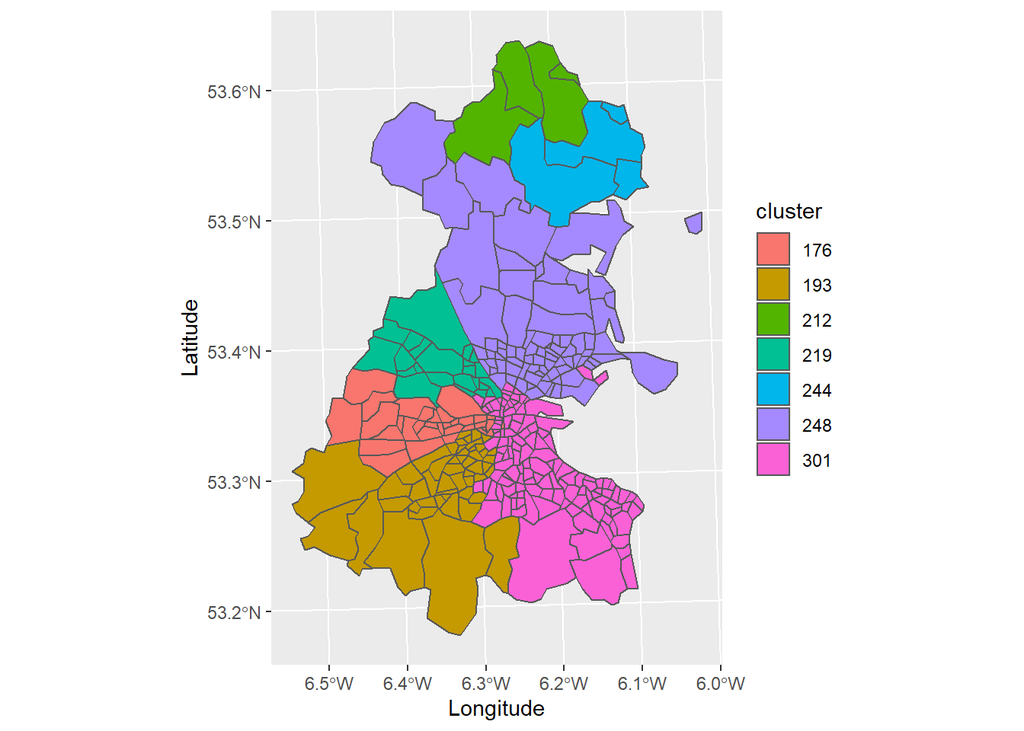

```r
dub_eds2 <- dub_eds
dub_eds2 <- dub_eds2 %>% left_join(cl2$lma$clusterList,copy=TRUE, by='community')
dub_eds2$cluster <- as.character(dub_eds2$cluster)

trips_to_work2 <- dub_trips2 %>%
group_by(community_work) %>%
summarise(amount=sum(amount)) %>%
rename(community=community_work)

dub_eds2 <- dub_eds2 %>% left_join(trips_to_work2)

ggplot(dub_eds2, aes(fill=cluster)) +
  xlab("Longitude") + ylab("Latitude") +
  geom_sf()
```

```r
library(LabourMarketAreas)
dub_trips3 <- dub_trips

cl3 <- findClusters(dub_trips3,15000,0.5,60000,0.75,idcom_type='char')
```

```
## [1] "The algorithm has converged."
```

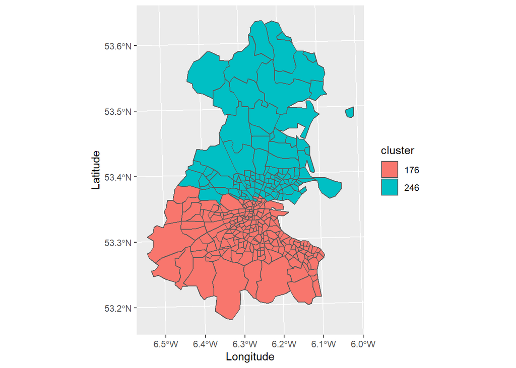

```r
dub_eds3 <- dub_eds
dub_eds3 <- dub_eds3 %>% left_join(cl3$lma$clusterList,copy=TRUE, by='community')
dub_eds3$cluster <- as.character(dub_eds3$cluster)

trips_to_work3 <- dub_trips3 %>%
group_by(community_work) %>%
summarise(amount=sum(amount)) %>%
rename(community=community_work)

dub_eds3 <- dub_eds3 %>% left_join(trips_to_work3)
ggplot(dub_eds3, aes(fill=cluster)) +
  xlab("Longitude") + ylab("Latitude") +
  geom_sf()
```

This travel to work area splits Dublin county into two regions. What’s interesting about this is the socio-economic parallels it holds with the real world. North Dublin and South Dublin, represent to vastly different cultural, economic and geographical regions. This iteration of the Coombes & Bond algorithm has captured it.

```r
library(LabourMarketAreas)
dub_trips4 <- dub_trips

cl4 <- findClusters(dub_trips3,15000,0.5,80000,0.9,idcom_type='char')
```

```
## [1] "The algorithm has converged."
```

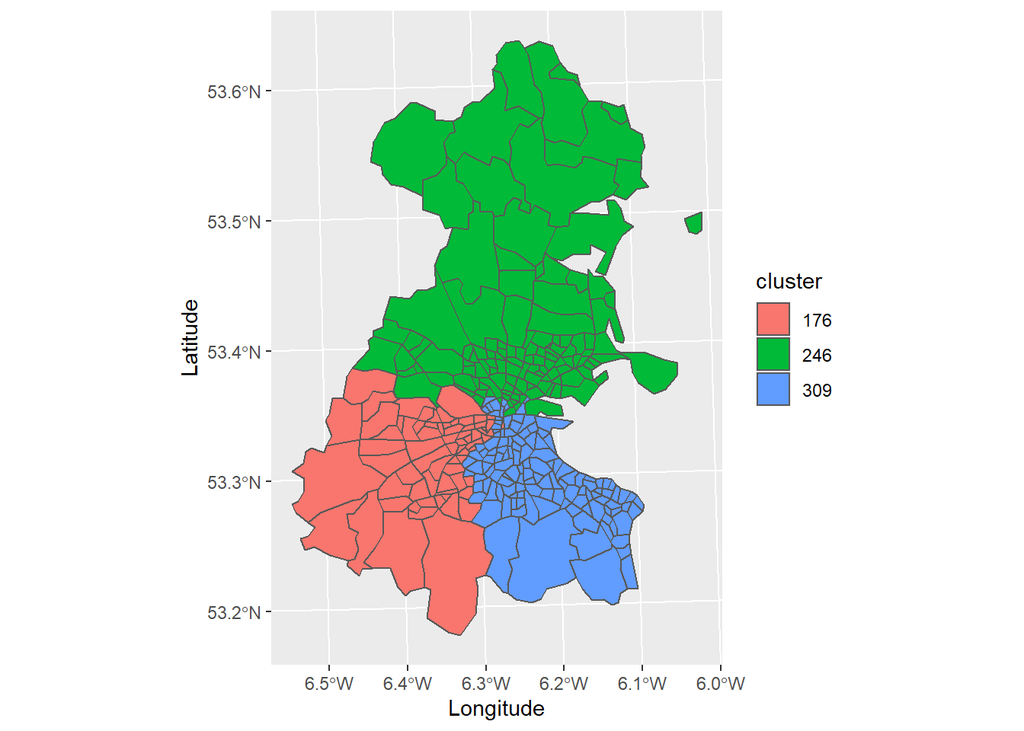

```r
dub_eds4 <- dub_eds
dub_eds4<- dub_eds4 %>% left_join(cl4$lma$clusterList,copy=TRUE, by='community')
dub_eds4$cluster <- as.character(dub_eds4$cluster)

trips_to_work4 <- dub_trips4 %>%
group_by(community_work) %>%
summarise(amount=sum(amount)) %>%
rename(community=community_work)

dub_eds4 <- dub_eds4 %>% left_join(trips_to_work4)
ggplot(dub_eds4, aes(fill=cluster)) +
  xlab("Longitude") + ylab("Latitude") +
  geom_sf()
```

For the final travel to work area, I have moved the parameters to the other side of the spectrum advocating for a very large target size and self-containment. This, with the most stringent of parameters, provided us with another unique set of travel to work zones, with 3 regions. However, this goes against my previous theory that the algorithm is not that sensitive to different variables, as clearly it is sensitive at the higher end of the self-containment measures. Maybe sensitivity isn’t linear?